# Модель машинного обучения для управления рисками и отбора бурёнок в поголовье стада молочного хозяйства «Вольный луг».

В нашем распоряжении данные, предоставленные владельцем молочного хозяйства «Вольный луг» и данные, предоставленные ассоциацией пастбищ «ЭкоФерма»:

- `ferma_main.csv` содержит данные о стаде молочного хозяйства «Вольный луг» на текущий момент, в том числе характеристики коров, корма, пастбищ и молока;
- `ferma_dad.csv` хранит имя папы каждой коровы в стаде молочного хозяйства «Вольный луг»;
- `cow_buy.csv` содержит данные о коровах «ЭкоФермы», предлагаемых к покупке.

**Цель машинного обучения** - разработать модель, позволяющую управлять рисками и принимать объективное решение о покупке коров, соответствующих запросам по качеству молока и выполнению плана развития молочного хозяйства (не менее 6000 кг молока в год от каждой буренки).

*Обучение проведем по следующим этапам*:

1. Изучим содержание данных, выявим наличие данных, требующих их предобработки (неудобный тип данных, дубликаты и пропуски).
2. Проведем предобработку данных:
   - приведем к удобному формату данных;
   - удалим дубликаты при наличии;
   - заполним пропуски значений, где это возможно;
   - добавим при необходимости дополнительные столбцы с данными.
3. Проведем исследовательский анализ данных: статистический анализ признаков для определения распределения количественных признаков и других особенностей.
4. Проведем корреляционный анализ данных для определения взаимосвязей между признаками.
5. Для прогноза признака "удой" подберем и обучим модель простой линейной регрессии.
6. Для прогноза признака "вкус молока" обучим модель логистической регрессии.
7. Оформим полученные результаты.

```python
# импортируем необходимые библиотеки:
import pandas as pd
import numpy as np
import matplotlib.pyplot as plt
import scipy.stats as st
from scipy.stats import spearmanr
import seaborn as sns
from sklearn.model_selection import train_test_split
from sklearn.preprocessing import OneHotEncoder, StandardScaler
from sklearn.linear_model import LinearRegression, LogisticRegression
from sklearn.metrics import r2_score, mean_absolute_error, mean_squared_error, accuracy_score, recall_score, precision_score, confusion_matrix
```

## 1. Загрузка данных

### 1.1. Данные о стаде фермера на текущий момент:

```python
ferma = pd.read_csv ('/datasets/ferma_main.csv', sep=';', decimal=',')
ferma.head()
```

|  | id | Удой, кг | ЭКЕ (Энергетическая кормовая единица) | Сырой протеин, г | СПО (Сахаро-протеиновое соотношение) | Порода | Тип пастбища | порода папы_быка | Жирность,% | Белок,% | Вкус молока | Возраст |
| --- | --- | --- | --- | --- | --- | --- | --- | --- | --- | --- | --- | --- |
| 0 | 1 | 5863 | 14.2 | 1743 | 0.890 | Вис Бик Айдиал | Равнинное | Айдиал | 3.58 | 3.076 | вкусно | более_2_лет |
| 1 | 2 | 5529 | 12.8 | 2138 | 0.890 | Вис Бик Айдиал | Равнинные | Соверин | 3.54 | 3.079 | вкусно | менее_2_лет |
| 2 | 3 | 5810 | 14.0 | 1854 | 0.885 | РефлешнСоверинг | Холмистое | Соверин | 3.59 | 3.074 | не вкусно | более_2_лет |
| 3 | 4 | 5895 | 12.4 | 2012 | 0.885 | РефлешнСоверинг | Холмистое | Айдиал | 3.40 | 3.075 | не вкусно | более_2_лет |
| 4 | 5 | 5302 | 12.8 | 1675 | 0.885 | Вис Бик Айдиал | Равнинные | Соверин | 3.73 | 3.073 | вкусно | менее_2_лет |

```python
ferma.shape
```

```
(634, 12)
```

### 1.2. Данные о папах коров в стаде фермера:

```python
dads = pd.read_csv ('/datasets/ferma_dad.csv', sep=';')
dads.head()
```

|  | id | Имя Папы |
| --- | --- | --- |
| 0 | 1 | Буйный |
| 1 | 2 | Соловчик |
| 2 | 3 | Барин |
| 3 | 4 | Буйный |
| 4 | 5 | Барин |

```python
dads.shape
```

```
(629, 2)
```

### 1.3. Данные о коровах «ЭкоФермы», которых фермер рассматривает к покупке:

```python
cow_buy = pd.read_csv ('/datasets/cow_buy.csv', sep=';',decimal=',')
cow_buy.head()
```

|  | Порода | Тип пастбища | порода папы_быка | Имя_папы | Текущая_жирность,% | Текущий_уровень_белок,% | Возраст |
| --- | --- | --- | --- | --- | --- | --- | --- |
| 0 | Вис Бик Айдиал | холмистое | Айдиал | Геркулес | 3.58 | 3.076 | более_2_лет |
| 1 | Вис Бик Айдиал | равнинное | Соверин | Буйный | 3.54 | 3.081 | менее_2_лет |
| 2 | РефлешнСоверинг | равнинное | Соверин | Барин | 3.59 | 3.074 | более_2_лет |
| 3 | РефлешнСоверинг | холмистое | Айдиал | Буйный | 3.40 | 3.061 | более_2_лет |
| 4 | РефлешнСоверинг | равнинное | Айдиал | Буйный | 3.64 | 3.074 | более_2_лет |

```python
cow_buy.shape
```

```
(20, 7)
```

Предоставленные исходные данные для работы содержат информацию о 634 буренках в действующем стаде фермы, информацию о 629 папах буренок и информацию о 20 буренках, предлагаемых к покупке.

## 2. Предобработка данных

### 2.1. Наименования столбцов

Приведем **наименования столбцов** в датафреймах к более удобному:

```python
ferma.rename(columns = {'Удой, кг':'milk_yield_kg',
                 'ЭКЕ (Энергетическая кормовая единица)' : 'EKE',
                 'Сырой протеин, г' : 'row_protein_g',
                 'СПО (Сахаро-протеиновое соотношение)' : 'SPO',
                 'Порода' : 'breed',
                 'Тип пастбища' : 'pasture_type',
                 'порода папы_быка' : 'dads_breed',
                 'Жирность,%' : 'fat_%',
                 'Белок,%' : 'protein_%',
                 'Вкус молока' : 'milk_taste',
                 'Возраст' : 'age'},
             inplace = True)
ferma.sample()
```

|  | id | milk_yield_kg | EKE | row_protein_g | SPO | breed | pasture_type | dads_breed | fat_% | protein_% | milk_taste | age |
| --- | --- | --- | --- | --- | --- | --- | --- | --- | --- | --- | --- | --- |
| 620 | 621 | 6813 | 14.5 | 1712 | 0.96 | РефлешнСоверинг | Равнинное | Айдиал | 3.72 | 3.075 | вкусно | более_2_лет |

```python
dads.rename(columns = {'Имя Папы':'dads_name'}, inplace = True)
dads.sample()
```

|  | id | dads_name |
| --- | --- | --- |
| 133 | 134 | Буйный |

```python
cow_buy.rename(columns = {'Порода' : 'breed',
                 'Тип пастбища' : 'pasture_type',
                 'порода папы_быка' : 'dads_breed',
                 'Имя_папы' : 'dads_name',
                 'Текущая_жирность,%' : 'current_fat_%',
                 'Текущий_уровень_белок,%' : 'current_protein_%',
                 'Возраст' : 'age'},
             inplace = True)
cow_buy.sample()
```

|  | breed | pasture_type | dads_breed | dads_name | current_fat_% | current_protein_% | age |
| --- | --- | --- | --- | --- | --- | --- | --- |
| 11 | РефлешнСоверинг | равнинное | Соверин | Геркулес | 3.73 | 3.073 | более_2_лет |

### 2.2. Типы данных и пропуски в данных

Проверим **типы данных** и **наличие пропусков** в данных:

```python
ferma.info()
```

```
<class 'pandas.core.frame.DataFrame'>
RangeIndex: 634 entries, 0 to 633
Data columns (total 12 columns):
 #   Column         Non-Null Count  Dtype
---  ------         --------------  -----
 0   id             634 non-null    int64
 1   milk_yield_kg  634 non-null    int64
 2   EKE            634 non-null    float64
 3   row_protein_g  634 non-null    int64
 4   SPO            634 non-null    float64
 5   breed          634 non-null    object
 6   pasture_type   634 non-null    object
 7   dads_breed     634 non-null    object
 8   fat_%          634 non-null    float64
 9   protein_%      634 non-null    float64
 10  milk_taste     634 non-null    object
 11  age            634 non-null    object
dtypes: float64(4), int64(3), object(5)
memory usage: 59.6+ KB
```

Файл с данными о стаде фермера содержит информацию о 634 коровах. Пропуски в данных файла `ferma` не обнаружены, но типы данных стоит привести к более удобным: id коров преобразуем в строковый тип данных.

```python
ferma['id'] = ferma['id'].astype('str')
```

```python
ferma.info()
```

```
<class 'pandas.core.frame.DataFrame'>
RangeIndex: 634 entries, 0 to 633
Data columns (total 12 columns):
 #   Column         Non-Null Count  Dtype
---  ------         --------------  -----
 0   id             634 non-null    object
 1   milk_yield_kg  634 non-null    int64
 2   EKE            634 non-null    float64
 3   row_protein_g  634 non-null    int64
 4   SPO            634 non-null    float64
 5   breed          634 non-null    object
 6   pasture_type   634 non-null    object
 7   dads_breed     634 non-null    object
 8   fat_%          634 non-null    float64
 9   protein_%      634 non-null    float64
 10  milk_taste     634 non-null    object
 11  age            634 non-null    object
dtypes: float64(4), int64(2), object(6)
memory usage: 59.6+ KB
```

```python
#общая информация о файле с данными о папах коров:
dads.info()
```

```
<class 'pandas.core.frame.DataFrame'>
RangeIndex: 629 entries, 0 to 628
Data columns (total 2 columns):
 #   Column     Non-Null Count  Dtype
---  ------     --------------  -----
 0   id         629 non-null    int64
 1   dads_name  629 non-null    object
dtypes: int64(1), object(1)
memory usage: 10.0+ KB
```

Файл с информацией о папах коров фермы содержит 629 строк без пропусков. В нем также изменим тип данных столбца id на более подходящий по содержанию строковый тип:

```python
dads['id'] = dads['id'].astype('str')
dads.info()
```

```
<class 'pandas.core.frame.DataFrame'>
RangeIndex: 629 entries, 0 to 628
Data columns (total 2 columns):
 #   Column     Non-Null Count  Dtype
---  ------     --------------  -----
 0   id         629 non-null    object
 1   dads_name  629 non-null    object
dtypes: object(2)
memory usage: 10.0+ KB
```

```python
#общая информация о файле с данными о папах коров:
cow_buy.info()
```

```
<class 'pandas.core.frame.DataFrame'>
RangeIndex: 20 entries, 0 to 19
Data columns (total 7 columns):
 #   Column             Non-Null Count  Dtype
---  ------             --------------  -----
 0   breed              20 non-null     object
 1   pasture_type       20 non-null     object
 2   dads_breed         20 non-null     object
 3   dads_name          20 non-null     object
 4   current_fat_%      20 non-null     float64
 5   current_protein_%  20 non-null     float64
 6   age                20 non-null     object
dtypes: float64(2), object(5)
memory usage: 1.2+ KB
```

Файл с информацией о коровах, предлагаемых к покупке, содержит информацию о 20 коровах, и не содержит пропусков в данных, типы данных соответствуют содержанию.

### 2.3. Дубликаты

Проверим данные датафреймов на **наличие дубликатов** в них:

```python
ferma.duplicated().sum()
```

```
5
```

```python
ferma = ferma.drop_duplicates().reset_index(drop=True)
ferma.shape
```

```
(629, 12)
```

Файл с данными коров фермы содержал 5 дубликатов, после удаления которых в файле остались данные о 629 буренках.

```python
dads.duplicated().sum()
```

```
0
```

```python
cow_buy.duplicated().sum()
```

```
4
```

Файл с информацией о папах бурёнок не содержит дубликатов. Файл с данными о коровах, предлагаемых к покупке, содержит 4 дубликата, вместе с тем, т.к. файл не содержит идентифицирующих признаков коров (id или имени), то возможно предположить, что к продаже предлагаются несколько схожих коров, имеющих одних и тех же родителей и похожие характеристики молока.

#### 2.3.1. Неявные дубликаты

Также проверим файлы с данными на наличие неявных дубликатов, выведя уникальные значения в столбцах со строковым типом данных

```python
# наличие неявных дубликатов в файле с данными о стаде фермы:
col = ['breed', 'pasture_type', 'dads_breed', 'milk_taste', 'age']
for i in col:
    print (i, ':', ferma[i].unique())
```

```
breed : ['Вис Бик Айдиал' 'РефлешнСоверинг']
pasture_type : ['Равнинное' 'Равнинные' 'Холмистое']
dads_breed : ['Айдиал' 'Соверин' 'Айдиалл']
milk_taste : ['вкусно' 'не вкусно']
age : ['более_2_лет' 'менее_2_лет']
```

Неявные дубликаты обнаружены в 2 столбцах файла "ферма" - pasture_type и dads_breed. Исправим это.

```python
ferma['pasture_type'] = ferma['pasture_type'].replace('Равнинные', 'Равнинное')
ferma['dads_breed'] = ferma['dads_breed'].replace('Айдиалл', 'Айдиал')
for i in col:
    print (i, ':', ferma[i].unique())
```

```
breed : ['Вис Бик Айдиал' 'РефлешнСоверинг']
pasture_type : ['Равнинное' 'Холмистое']
dads_breed : ['Айдиал' 'Соверин']
milk_taste : ['вкусно' 'не вкусно']
age : ['более_2_лет' 'менее_2_лет']
```

```python
# наличие неявных дубликатов в файле с данными о папах коров фермы:
dads['dads_name'].unique()
```

```
array(['Буйный', 'Соловчик', 'Барин', 'Геркулес'], dtype=object)
```

Файл с данными о папах буренок фермы не содержит неявных дубликатов.

```python
# наличие неявных дубликатов в файле с данными о коровах, предлагаемых к покупке:
col = ['breed', 'pasture_type', 'dads_breed', 'dads_name', 'age']
for i in col:
    print (i, ':', cow_buy[i].unique())
```

```
breed : ['Вис Бик Айдиал' 'РефлешнСоверинг']
pasture_type : ['холмистое' 'равнинное']
dads_breed : ['Айдиал' 'Соверин']
dads_name : ['Геркулес' 'Буйный' 'Барин' 'Соловчик']
age : ['более_2_лет' 'менее_2_лет']
```

Файл с данными о коровах, предлагаемых к покупке, не содержит неявных дубликатов, вместе с тем при сравнении в написании типов пастбищ есть различия с данными в файле "ферма". Приведем их к единному виду:

```python
cow_buy['pasture_type'] = cow_buy['pasture_type'].replace('холмистое', 'Холмистое').replace('равнинное', 'Равнинное')
for i in col:
    print (i, ':', cow_buy[i].unique())
```

```
breed : ['Вис Бик Айдиал' 'РефлешнСоверинг']
pasture_type : ['Холмистое' 'Равнинное']
dads_breed : ['Айдиал' 'Соверин']
dads_name : ['Геркулес' 'Буйный' 'Барин' 'Соловчик']
age : ['более_2_лет' 'менее_2_лет']
```

## 3. Исследовательский анализ данных

Проведем ислледовательский анализ данных с информацией о стаде фермы.

### 3.1. Распределение буренок в стаде по категориальным признакам

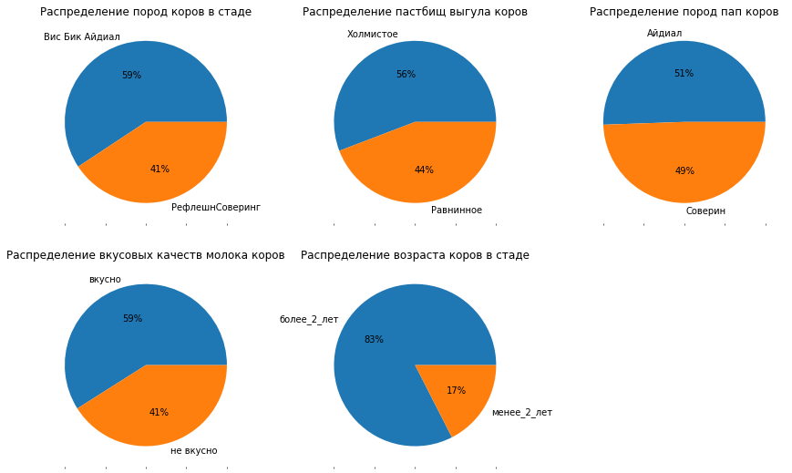

```python
col = ['breed', 'pasture_type', 'dads_breed', 'milk_taste', 'age']
fig, ax = plt.subplots(2, 3, figsize=(15, 9), sharex=True)
ferma['breed'].value_counts().plot(kind='pie', autopct='%1.0f%%', ax = ax [0, 0], title='Распределение пород коров в стаде', ylabel='')
ferma['pasture_type'].value_counts().plot(kind='pie', autopct='%1.0f%%', ax = ax [0, 1], title='Распределение пастбищ выгула коров', ylabel='')
ferma['dads_breed'].value_counts().plot(kind='pie', autopct='%1.0f%%', ax = ax [0, 2], title='Распределение пород пап коров', ylabel='')
ferma['milk_taste'].value_counts().plot(kind='pie', autopct='%1.0f%%', ax = ax [1, 0], title='Распределение вкусовых качеств молока коров', ylabel='')
ferma['age'].value_counts().plot(kind='pie', autopct='%1.0f%%', ax = ax [1, 1], title='Распределение возраста коров в стаде', ylabel='')
fig.delaxes(ax[1,2])
```

Графики показывают, что:

- в стаде больше коров породы Вис Бик Айдиал (59%);
- больше коров (56%) пасутся на холмистых пастбищах;
- породы пап распределены примерно равномерно;
- 59 % коров имеют хорошие вкусовые качества молока;
- в стаде большинство коров (83%) старше 2 лет.

### 3.2. Распределение количественных показателей буренок в стаде.

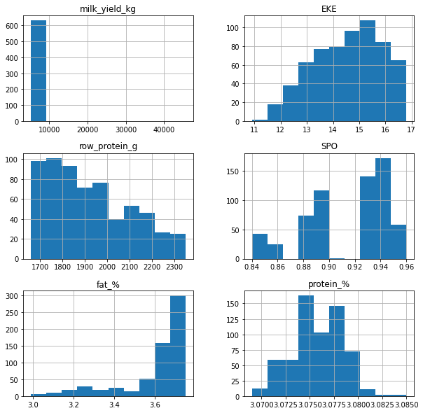

```python
#посмотрим на распределение количественных признаков на гистограммах
ferma.hist(bins=10, figsize=(10, 10));
```

```python
# посмотрим на описательную статистику
ferma.describe()
```

|  | milk_yield_kg | EKE | row_protein_g | SPO | fat_% | protein_% |
| --- | --- | --- | --- | --- | --- | --- |
| count | 629.000000 | 629.000000 | 629.000000 | 629.000000 | 629.000000 | 629.000000 |
| mean | 6188.750397 | 14.543879 | 1923.364070 | 0.913116 | 3.603657 | 3.075671 |
| std | 1644.795489 | 1.306408 | 182.956251 | 0.032203 | 0.168656 | 0.002549 |
| min | 5204.000000 | 10.900000 | 1660.000000 | 0.840000 | 2.990000 | 3.069000 |
| 25% | 5751.000000 | 13.500000 | 1771.000000 | 0.890000 | 3.590000 | 3.074000 |
| 50% | 6133.000000 | 14.700000 | 1888.000000 | 0.930000 | 3.650000 | 3.076000 |
| 75% | 6501.000000 | 15.600000 | 2062.000000 | 0.940000 | 3.720000 | 3.077000 |
| max | 45616.000000 | 16.800000 | 2349.000000 | 0.960000 | 3.750000 | 3.085000 |

Исходя из описательной статистики данных, данные в столбцах показатели EKE, row_protein*g, SPO и protein*% не имеют аномальных значений. Отдельно стоит рассмотреть данные в столцах milk_yield*kg b fat*%, т. к. в них присутствуют выбросы.

```python
# показатель удоя модока в кг
ferma[ferma['milk_yield_kg'] > 10000]
```

|  | id | milk_yield_kg | EKE | row_protein_g | SPO | breed | pasture_type | dads_breed | fat_% | protein_% | milk_taste | age |
| --- | --- | --- | --- | --- | --- | --- | --- | --- | --- | --- | --- | --- |
| 16 | 17 | 45616 | 11.5 | 1675 | 0.93 | Вис Бик Айдиал | Холмистое | Айдиал | 3.22 | 3.076 | вкусно | более_2_лет |

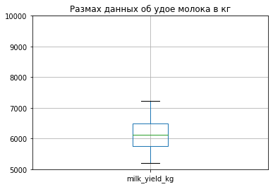

```python
ferma[['milk_yield_kg']].boxplot()
plt.ylim(5000, 10000)
plt.title('Размах данных об удое молока в кг');
```

В столбце с данными об удое молока присутствует строка с аномально большим значением, которую лучше удалить для лучшей работы модели.

```python
ferma = ferma[ferma['milk_yield_kg'] < 10000]
ferma.shape
```

```
(628, 12)
```

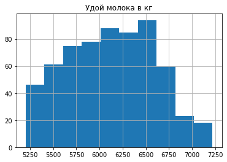

```python
ferma['milk_yield_kg'].hist()
plt.title('Удой молока в кг');
```

Данные очищены от выбросов и наглядно показывают, что один из целевых признаков - удой молока - имеет значение от 5200 до 7250 кг с наиболее частым значением около 6500 кг.

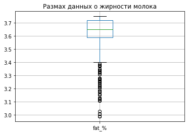

```python
# показатель жирности модока
ferma[['fat_%']].boxplot()
plt.title('Размах данных о жирности молока');
```

```python
ferma['fat_%'].describe()
```

```
count    628.000000
mean       3.604268
std        0.168093
min        2.990000
25%        3.590000
50%        3.650000
75%        3.720000
max        3.750000
Name: fat_%, dtype: float64
```

```python
ferma.shape
```

```
(628, 12)
```

После удаления аномально высокого показателя удоя молока, в файле "ферма" для последующего анализа остались характеристики 628 коров.

## 4. Корреляционный анализ данных

Для понимания взаимосвязей между признаками, характеризующими коров в стаде, построим матрицы корреляции и рассчитаем коэффициенты корреляции.

```
                                              Матрица корреляции признаков
```

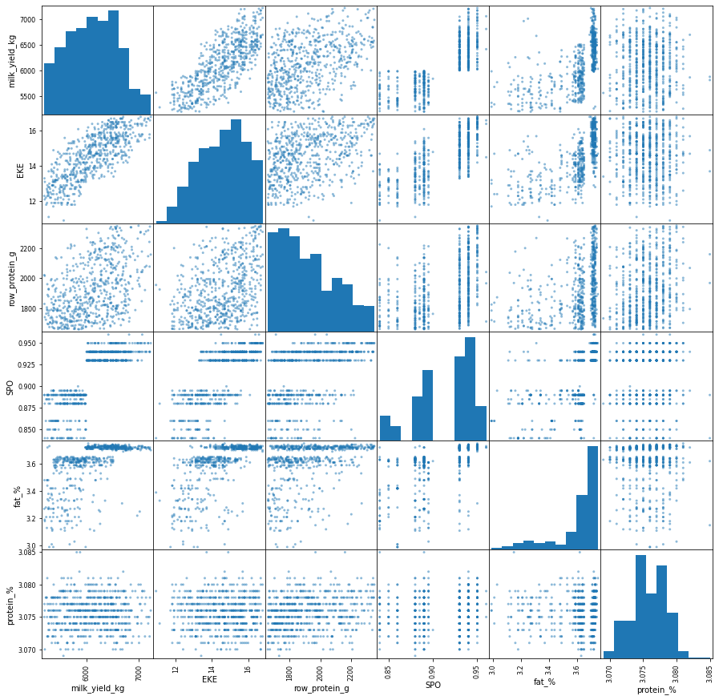

```python
print('Матрица корреляции признаков'.center(120))
pd.plotting.scatter_matrix(ferma, figsize=(15, 15));
```

```python
# коэффициент корреляции Пирсона для количественных признаков
ferma.corr()
```

|  | milk_yield_kg | EKE | row_protein_g | SPO | fat_% | protein_% |
| --- | --- | --- | --- | --- | --- | --- |
| milk_yield_kg | 1.000000 | 0.765098 | 0.446731 | 0.806339 | 0.600902 | 0.002966 |
| EKE | 0.765098 | 1.000000 | 0.387875 | 0.749007 | 0.637279 | -0.008939 |
| row_protein_g | 0.446731 | 0.387875 | 1.000000 | 0.446332 | 0.357793 | 0.226802 |
| SPO | 0.806339 | 0.749007 | 0.446332 | 1.000000 | 0.629098 | 0.073718 |
| fat_% | 0.600902 | 0.637279 | 0.357793 | 0.629098 | 1.000000 | -0.026542 |
| protein_% | 0.002966 | -0.008939 | 0.226802 | 0.073718 | -0.026542 | 1.000000 |

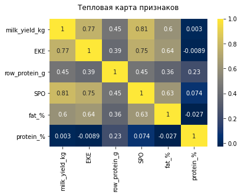

```python
sns.heatmap(ferma.corr(), annot=True, cmap='cividis')
plt.title('Тепловая карта признаков', pad=15);
```

```python
# выведем коэффициэнт Спирмена:
k_spearman = []
for i in ferma.columns:
    k = spearmanr(ferma['milk_yield_kg'], ferma[i])
    k_spearman.append(k)
pd.DataFrame (k_spearman, columns=['correlation', 'pvalue'], index = ferma.columns)
```

|  | correlation | pvalue |
| --- | --- | --- |
| id | -0.005126 | 8.979893e-01 |
| milk_yield_kg | 1.000000 | 0.000000e+00 |
| EKE | 0.765144 | 8.359783e-122 |
| row_protein_g | 0.437543 | 9.395930e-31 |
| SPO | 0.787904 | 6.236377e-134 |
| breed | 0.070471 | 7.761710e-02 |
| pasture_type | 0.118968 | 2.826557e-03 |
| dads_breed | -0.385846 | 1.001756e-23 |
| fat_% | 0.688506 | 2.103531e-89 |
| protein_% | -0.005701 | 8.866217e-01 |
| milk_taste | -0.102273 | 1.032994e-02 |
| age | -0.647025 | 9.172696e-76 |

Корреляционный анализ показал, что присутствует высокая связь между целевым признаком "удой молока" и входными признаками "EKE" и "SPO", умеренная связь между целевым признаком и входными признаками "row_protein_g" и "dads*breed" и заметная связь между целевым признаком и входными признаками "fat*%" и "age". Мультиколлинеарность (коэффициент корреляции более 0,9 по модулю) между входными признаками не наблюдается. При этом показатели "SPO", "fat*%" и "protein*%" имеют нелинейный характер.

Рассмотрим влияние входного признака питательности корма коровы "EKE" (энергетическая кормовая единица) на целевой разных категорий:

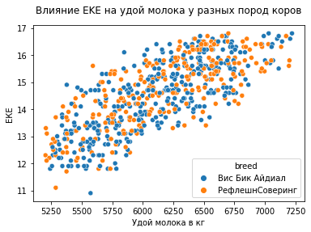

```python
sns.scatterplot(x='milk_yield_kg', y='EKE', hue='breed', data=ferma)
plt.title('Влияние EKE на удой молока у разных пород коров', pad=15)
plt.xlabel('Удой молока в кг') # подпись для оси х
plt.ylabel('ЕКЕ'); # подпись для оси y
```

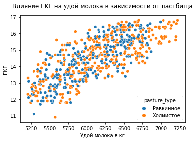

```python
sns.scatterplot(x='milk_yield_kg', y='EKE', hue='pasture_type', data=ferma)
plt.title('Влияние EKE на удой молока в зависимости от пастбища', pad=15)
plt.xlabel('Удой молока в кг') # подпись для оси х
plt.ylabel('ЕКЕ'); # подпись для оси y
```

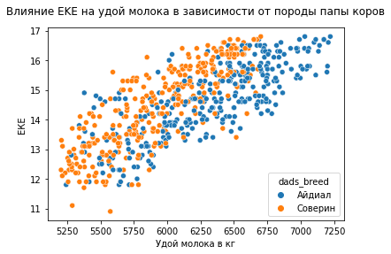

```python
sns.scatterplot(x='milk_yield_kg', y='EKE', hue='dads_breed', data=ferma)
plt.title('Влияние EKE на удой молока в зависимости от породы папы коров', pad=15)
plt.xlabel('Удой молока в кг') # подпись для оси х
plt.ylabel('ЕКЕ'); # подпись для оси y
```

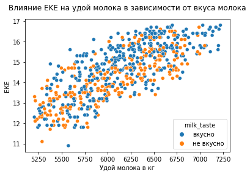

```python
sns.scatterplot(x='milk_yield_kg', y='EKE', hue='milk_taste', data=ferma)
plt.title('Влияние EKE на удой молока в зависимости от вкуса молока', pad=15)
plt.xlabel('Удой молока в кг') # подпись для оси х
plt.ylabel('ЕКЕ'); # подпись для оси y
```

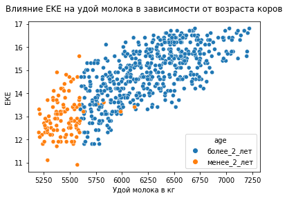

```python
sns.scatterplot(x='milk_yield_kg', y='EKE', hue='age', data=ferma)
plt.title('Влияние EKE на удой молока в зависимости от возраста коров', pad=15)
plt.xlabel('Удой молока в кг') # подпись для оси х
plt.ylabel('ЕКЕ'); # подпись для оси y
```

Линейная зависимость сильнее прослеживается у коров, папы которых породы Айдиал, и коров старше 2 лет.

Проверим, влияет ли на целевой признак кто был папой коровы. Для этого добавим в файл с данными о коровах фермы столбец с информацией об их папах.

```python
ferma_with_dads = ferma.merge(dads, on='id', how='left')
ferma_with_dads.shape
```

```
(628, 13)
```

```python
# рассчитаем коэффициент корреляции Спиремена:
spearmanr(ferma_with_dads['milk_yield_kg'], ferma_with_dads['dads_name'])
```

```
SpearmanrResult(correlation=0.23315061522963648, pvalue=3.3639339358929293e-09)
```

Коэффициент корреляции Спирмена не показал заметной зависимости целевого показателя "удой молока" от параметра "папа коровы".

## 5. Обучение модели линейной регрессии для прогноза удоя молока

Для прогноза удоя молока в кг в год у коров, предлагаемых к покупке, обучим модели простой линейной регрессии на данных коров фермы.

### 5.1. Модель № 1

Подготовим данные датасета `ferma_main.csv` и обучим на них первую модель. Исключим из данных признаки, характеризующие вкус молока, которые маловероятно имеют влияние на удой молока - "protein_%", "milk*taste" и "fat*%". Выделим целевой признак - "milk_yield_kg".

```python
ferma.columns
```

```
Index(['id', 'milk_yield_kg', 'EKE', 'row_protein_g', 'SPO', 'breed',
       'pasture_type', 'dads_breed', 'fat_%', 'protein_%', 'milk_taste',
       'age'],
      dtype='object')
```

```python
X = ferma.drop(['id', 'milk_yield_kg', 'protein_%', 'fat_%', 'milk_taste'], axis=1)
y = ferma['milk_yield_kg']
X.head()
```

|  | EKE | row_protein_g | SPO | breed | pasture_type | dads_breed | age |
| --- | --- | --- | --- | --- | --- | --- | --- |
| 0 | 14.2 | 1743 | 0.890 | Вис Бик Айдиал | Равнинное | Айдиал | более_2_лет |
| 1 | 12.8 | 2138 | 0.890 | Вис Бик Айдиал | Равнинное | Соверин | менее_2_лет |
| 2 | 14.0 | 1854 | 0.885 | РефлешнСоверинг | Холмистое | Соверин | более_2_лет |
| 3 | 12.4 | 2012 | 0.885 | РефлешнСоверинг | Холмистое | Айдиал | более_2_лет |
| 4 | 12.8 | 1675 | 0.885 | Вис Бик Айдиал | Равнинное | Соверин | менее_2_лет |

```python
# разделение на тренировочную и тестовую выборки
RANDOM_STATE = 42
X_train, X_test, y_train, y_test = train_test_split(
    X, y, random_state=RANDOM_STATE)
print('Размер тренировочной выборки =', X_train.shape)
print('Размер тестовой выборки =', X_test.shape)
```

```
Размер тренировочной выборки = (471, 7)
Размер тестовой выборки = (157, 7)
```

```python
# нормализуем категориальные признаки с помощью One-Hot Encoding
# масштабируем количественные признаки с помощью StandardScaler
cat_col_names = ['breed', 'pasture_type', 'dads_breed', 'age']
num_col_names = ['EKE', 'row_protein_g', 'SPO']

encoder = OneHotEncoder(drop='first', sparse=False)
X_train_ohe = encoder.fit_transform(X_train[cat_col_names])
X_test_ohe = encoder.transform(X_test[cat_col_names])

encoder_col_names = encoder.get_feature_names()

scaler = StandardScaler()
X_train_scaled = scaler.fit_transform(X_train[num_col_names])
X_test_scaled = scaler.transform(X_test[num_col_names])

X_train_ohe = pd.DataFrame(X_train_ohe, columns=encoder_col_names)
X_test_ohe = pd.DataFrame(X_test_ohe, columns=encoder_col_names)

X_train_scaled = pd.DataFrame(X_train_scaled, columns=num_col_names)
X_test_scaled = pd.DataFrame(X_test_scaled, columns=num_col_names)

X_train = pd.concat([X_train_ohe, X_train_scaled], axis=1)
X_test = pd.concat([X_test_ohe, X_test_scaled], axis=1)
X_train.head()
```

|  | x0_РефлешнСоверинг | x1_Холмистое | x2_Соверин | x3_менее_2_лет | EKE | row_protein_g | SPO |
| --- | --- | --- | --- | --- | --- | --- | --- |
| 0 | 1.0 | 1.0 | 1.0 | 0.0 | 1.502378 | 1.079523 | 0.837130 |
| 1 | 1.0 | 1.0 | 1.0 | 1.0 | -1.557270 | -0.196920 | -0.703660 |
| 2 | 0.0 | 0.0 | 0.0 | 0.0 | 0.125537 | -1.386085 | -1.011818 |
| 3 | 0.0 | 1.0 | 0.0 | 0.0 | -0.103937 | 0.752230 | 0.837130 |
| 4 | 0.0 | 0.0 | 0.0 | 0.0 | -1.098323 | 0.828598 | -0.703660 |

```python
# обучение модели и получение предсказаний на тестовых данных
model_lr_1  = LinearRegression()
model_lr_1.fit(X_train, y_train)
predictions = model_lr_1.predict(X_test)
```

Для оценки качество модели рассчитаем коэффициент детерминации R² и проанализируем остатки с помощью графиков.

```python
r2_1 = r2_score(y_test, predictions)
# выведите полученное значение R2
print("R2 LinearRegression =", r2_1)
```

```
R2 LinearRegression = 0.7844078173416967
```

Значение коэффициента детерминации R2 близок к 1, модель хорошо предсказывает в 78% случаях.

```python
mae_1 = mean_absolute_error(y_test, predictions)
mse_1 = mean_squared_error(y_test, predictions)
print ('Среднее абсолютное отклонение:', mae_1)
print ('Среднее квадратичное отклонение:', mse_1)
```

```
Среднее абсолютное отклонение: 164.24194463474925
Среднее квадратичное отклонение: 43887.015009660514
```

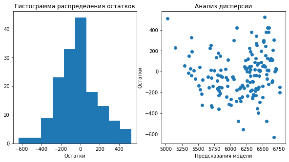

```python
# рассчитаем остатки:
residuals = y_test - predictions
# построим гистограмму частотности распределения и диаграмму рассеяния
fig, axes = plt.subplots(nrows=1, ncols=2, figsize=(10,5))
axes[0].hist(residuals)
axes[0].set_title('Гистограмма распределения остатков')
axes[0].set_xlabel('Остатки')

axes[1].scatter(predictions, residuals)
axes[1].set_xlabel('Предсказания модели')
axes[1].set_ylabel('Остатки')
axes[1].set_title('Анализ дисперсии')
plt.show()
```

Гистограмма распределения остатков показывает смещение распределения влево, т.е. модель имеет более оптимистичный прогноз. Анализ дисперсии же выявил увеличение разброса ошибок при предсказании большего объема удоя. Анализ остатков показывает, что модель следует улучшить.

### 5.2. Модель № 2

Необычное распределение имеет показатель "SPO", характеризующий сахаро-протеиновое отношение в корме коровы, - несколько пиков с падением до нуля. Попробуем улучшить модель, преобразовав этот показатель в категории до 0.9 и свыше 0.9

```python
ferma ['SPO'] = ferma ['SPO'].apply (lambda x: 'до_0.9' if x<=0.9 else 'свыше_0.9')
ferma.head()
```

|  | id | milk_yield_kg | EKE | row_protein_g | SPO | breed | pasture_type | dads_breed | fat_% | protein_% | milk_taste | age |
| --- | --- | --- | --- | --- | --- | --- | --- | --- | --- | --- | --- | --- |
| 0 | 1 | 5863 | 14.2 | 1743 | до_0.9 | Вис Бик Айдиал | Равнинное | Айдиал | 3.58 | 3.076 | вкусно | более_2_лет |
| 1 | 2 | 5529 | 12.8 | 2138 | до_0.9 | Вис Бик Айдиал | Равнинное | Соверин | 3.54 | 3.079 | вкусно | менее_2_лет |
| 2 | 3 | 5810 | 14.0 | 1854 | до_0.9 | РефлешнСоверинг | Холмистое | Соверин | 3.59 | 3.074 | не вкусно | более_2_лет |
| 3 | 4 | 5895 | 12.4 | 2012 | до_0.9 | РефлешнСоверинг | Холмистое | Айдиал | 3.40 | 3.075 | не вкусно | более_2_лет |
| 4 | 5 | 5302 | 12.8 | 1675 | до_0.9 | Вис Бик Айдиал | Равнинное | Соверин | 3.73 | 3.073 | вкусно | менее_2_лет |

Также попробуем усилить линейную зависимость показателя "EKE" и целевого признака, возведя данные в столбце "EKE" в квадрат.

```python
# добавление нового признака
ferma ['EKE2'] = ferma ['EKE'] ** 2
ferma.head()
```

|  | id | milk_yield_kg | EKE | row_protein_g | SPO | breed | pasture_type | dads_breed | fat_% | protein_% | milk_taste | age | EKE2 |
| --- | --- | --- | --- | --- | --- | --- | --- | --- | --- | --- | --- | --- | --- |
| 0 | 1 | 5863 | 14.2 | 1743 | до_0.9 | Вис Бик Айдиал | Равнинное | Айдиал | 3.58 | 3.076 | вкусно | более_2_лет | 201.64 |
| 1 | 2 | 5529 | 12.8 | 2138 | до_0.9 | Вис Бик Айдиал | Равнинное | Соверин | 3.54 | 3.079 | вкусно | менее_2_лет | 163.84 |
| 2 | 3 | 5810 | 14.0 | 1854 | до_0.9 | РефлешнСоверинг | Холмистое | Соверин | 3.59 | 3.074 | не вкусно | более_2_лет | 196.00 |
| 3 | 4 | 5895 | 12.4 | 2012 | до_0.9 | РефлешнСоверинг | Холмистое | Айдиал | 3.40 | 3.075 | не вкусно | более_2_лет | 153.76 |
| 4 | 5 | 5302 | 12.8 | 1675 | до_0.9 | Вис Бик Айдиал | Равнинное | Соверин | 3.73 | 3.073 | вкусно | менее_2_лет | 163.84 |

```python
X = ferma.drop(['id', 'milk_yield_kg', 'protein_%', 'fat_%', 'milk_taste'], axis=1)
y = ferma['milk_yield_kg']
RANDOM_STATE = 42
X_train, X_test, y_train, y_test = train_test_split(
    X, y, random_state=RANDOM_STATE)
cat_col_names = ['SPO', 'breed', 'pasture_type', 'dads_breed', 'age']
num_col_names = ['EKE2', 'row_protein_g']

encoder = OneHotEncoder(drop='first', sparse=False)
X_train_ohe = encoder.fit_transform(X_train[cat_col_names])
X_test_ohe = encoder.transform(X_test[cat_col_names])

encoder_col_names = encoder.get_feature_names()

scaler = StandardScaler()
X_train_scaled = scaler.fit_transform(X_train[num_col_names])
X_test_scaled = scaler.transform(X_test[num_col_names])

X_train_ohe = pd.DataFrame(X_train_ohe, columns=encoder_col_names)
X_test_ohe = pd.DataFrame(X_test_ohe, columns=encoder_col_names)

X_train_scaled = pd.DataFrame(X_train_scaled, columns=num_col_names)
X_test_scaled = pd.DataFrame(X_test_scaled, columns=num_col_names)

X_train = pd.concat([X_train_ohe, X_train_scaled], axis=1)
X_test = pd.concat([X_test_ohe, X_test_scaled], axis=1)
X_train.head()
```

|  | x0_свыше_0.9 | x1_РефлешнСоверинг | x2_Холмистое | x3_Соверин | x4_менее_2_лет | EKE2 | row_protein_g |
| --- | --- | --- | --- | --- | --- | --- | --- |
| 0 | 1.0 | 1.0 | 1.0 | 1.0 | 0.0 | 1.577968 | 1.079523 |
| 1 | 0.0 | 1.0 | 1.0 | 1.0 | 1.0 | -1.511438 | -0.196920 |
| 2 | 0.0 | 0.0 | 0.0 | 0.0 | 0.0 | 0.082269 | -1.386085 |
| 3 | 1.0 | 0.0 | 1.0 | 0.0 | 0.0 | -0.150235 | 0.752230 |
| 4 | 0.0 | 0.0 | 0.0 | 0.0 | 0.0 | -1.102358 | 0.828598 |

```python
# обучение модели и получение предсказаний на тестовых данных
model_lr_2  = LinearRegression()
model_lr_2.fit(X_train, y_train)
predictions = model_lr_2.predict(X_test)
```

```python
r2_2 = r2_score(y_test, predictions)
# выведите полученное значение R2
print("R2 LinearRegression =", r2_2)
```

```
R2 LinearRegression = 0.8180879926867504
```

```python
mae_2 = mean_absolute_error(y_test, predictions)
mse_2 = mean_squared_error(y_test, predictions)
print ('Среднее абсолютное отклонение:', mae_2)
print ('Среднее квадратичное отклонение:', mse_2)
```

```
Среднее абсолютное отклонение: 149.03965222364596
Среднее квадратичное отклонение: 37030.911311136915
```

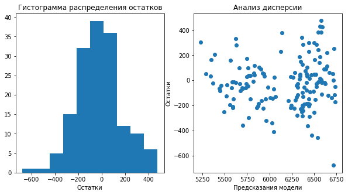

```python
# рассчитаем остатки:
residuals = y_test - predictions
# построим гистограмму частотности распределения и диаграмму рассеяния
fig, axes = plt.subplots(nrows=1, ncols=2, figsize=(10,5))
axes[0].hist(residuals)
axes[0].set_title('Гистограмма распределения остатков')
axes[0].set_xlabel('Остатки')

axes[1].scatter(predictions, residuals)
axes[1].set_xlabel('Предсказания модели')
axes[1].set_ylabel('Остатки')
axes[1].set_title('Анализ дисперсии')
plt.show()
```

Коэффициент детерминации повысился до 0.818, что означет что модель хорошо предсказывает в 82 % случаев. Гистограмма распределения остатков показывает более равномерное распределение. Это говорит о том, что у второй модели более стабильная ошибка на всех предсказаниях. Анализ дисперсии по-прежнему показывает увеличение разброса ошибки при предсказании большего объема удоя, но в меньшей степени, чем первая модель. Анализ остатков показывает, что модель следует продолжить улучшать.

### 5.3. Модель № 3.

Попробуем улучшить модель, добавив дополнительный признак из файла с наименованиями пап коров.

```python
ferma_with_dads = ferma.merge(dads, on='id', how='left')
X = ferma_with_dads.drop(['id', 'milk_yield_kg', 'protein_%', 'fat_%', 'milk_taste'], axis=1)
y = ferma_with_dads['milk_yield_kg']
X.head()
```

|  | EKE | row_protein_g | SPO | breed | pasture_type | dads_breed | age | EKE2 | dads_name |
| --- | --- | --- | --- | --- | --- | --- | --- | --- | --- |
| 0 | 14.2 | 1743 | до_0.9 | Вис Бик Айдиал | Равнинное | Айдиал | более_2_лет | 201.64 | Буйный |
| 1 | 12.8 | 2138 | до_0.9 | Вис Бик Айдиал | Равнинное | Соверин | менее_2_лет | 163.84 | Соловчик |
| 2 | 14.0 | 1854 | до_0.9 | РефлешнСоверинг | Холмистое | Соверин | более_2_лет | 196.00 | Барин |
| 3 | 12.4 | 2012 | до_0.9 | РефлешнСоверинг | Холмистое | Айдиал | более_2_лет | 153.76 | Буйный |
| 4 | 12.8 | 1675 | до_0.9 | Вис Бик Айдиал | Равнинное | Соверин | менее_2_лет | 163.84 | Барин |

```python
# разделение на тренировочную и тестовую выборки
RANDOM_STATE = 42
X_train, X_test, y_train, y_test = train_test_split(
    X, y, random_state=RANDOM_STATE)
X = ferma_with_dads.drop(['id', 'milk_yield_kg', 'protein_%', 'fat_%', 'milk_taste'], axis=1)
y = ferma_with_dads['milk_yield_kg']
RANDOM_STATE = 42
X_train, X_test, y_train, y_test = train_test_split(
    X, y, random_state=RANDOM_STATE)
cat_col_names = ['SPO', 'breed', 'pasture_type', 'dads_breed', 'age', 'dads_name']
num_col_names = ['EKE2', 'row_protein_g']

encoder = OneHotEncoder(drop='first', sparse=False)
X_train_ohe = encoder.fit_transform(X_train[cat_col_names])
X_test_ohe = encoder.transform(X_test[cat_col_names])

encoder_col_names = encoder.get_feature_names()

scaler = StandardScaler()
X_train_scaled = scaler.fit_transform(X_train[num_col_names])
X_test_scaled = scaler.transform(X_test[num_col_names])

X_train_ohe = pd.DataFrame(X_train_ohe, columns=encoder_col_names)
X_test_ohe = pd.DataFrame(X_test_ohe, columns=encoder_col_names)

X_train_scaled = pd.DataFrame(X_train_scaled, columns=num_col_names)
X_test_scaled = pd.DataFrame(X_test_scaled, columns=num_col_names)

X_train = pd.concat([X_train_ohe, X_train_scaled], axis=1)
X_test = pd.concat([X_test_ohe, X_test_scaled], axis=1)
X_train.head()
```

|  | x0_свыше_0.9 | x1_РефлешнСоверинг | x2_Холмистое | x3_Соверин | x4_менее_2_лет | x5_Буйный | x5_Геркулес | x5_Соловчик | EKE2 | row_protein_g |
| --- | --- | --- | --- | --- | --- | --- | --- | --- | --- | --- |
| 0 | 1.0 | 1.0 | 1.0 | 1.0 | 0.0 | 0.0 | 0.0 | 1.0 | 1.577968 | 1.079523 |
| 1 | 0.0 | 1.0 | 1.0 | 1.0 | 1.0 | 0.0 | 0.0 | 0.0 | -1.511438 | -0.196920 |
| 2 | 0.0 | 0.0 | 0.0 | 0.0 | 0.0 | 1.0 | 0.0 | 0.0 | 0.082269 | -1.386085 |
| 3 | 1.0 | 0.0 | 1.0 | 0.0 | 0.0 | 1.0 | 0.0 | 0.0 | -0.150235 | 0.752230 |
| 4 | 0.0 | 0.0 | 0.0 | 0.0 | 0.0 | 0.0 | 1.0 | 0.0 | -1.102358 | 0.828598 |

```python
# обучение модели и получение предсказаний на тестовых данных
model_lr_3  = LinearRegression()
model_lr_3.fit(X_train, y_train)
predictions = model_lr_3.predict(X_test)
```

```python
r2_3 = r2_score(y_test, predictions)
# выведите полученное значение R2
print("R2 LinearRegression =", r2_3)
```

```
R2 LinearRegression = 0.8247542745210406
```

```python
mae_3 = mean_absolute_error(y_test, predictions)
mse_3 = mean_squared_error(y_test, predictions)
print ('Среднее абсолютное отклонение:', mae_3)
print ('Среднее квадратичное отклонение:', mse_3)
```

```
Среднее абсолютное отклонение: 146.1630244536232
Среднее квадратичное отклонение: 35673.889886181954
```

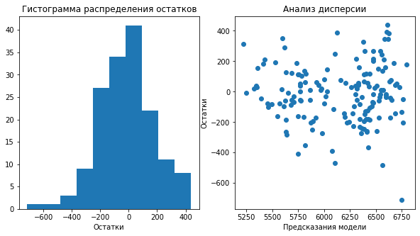

```python
# рассчитаем остатки:
residuals = y_test - predictions
# построим гистограмму частотности распределения и диаграмму рассеяния
fig, axes = plt.subplots(nrows=1, ncols=2, figsize=(10,5))
axes[0].hist(residuals)
axes[0].set_title('Гистограмма распределения остатков')
axes[0].set_xlabel('Остатки')

axes[1].scatter(predictions, residuals)
axes[1].set_xlabel('Предсказания модели')
axes[1].set_ylabel('Остатки')
axes[1].set_title('Анализ дисперсии')
plt.show()
```

Коэффициент детерминации повысился, модель теперь хорошо предсказывает в 82,5 % случаев. Гистограмма распределения остатков показывает распределение, схожее со второй моделью. Анализ же дисперсии показывает более равмномерное распределение остатков.

### 5.4. Прогноз удоя коров, рассматриваемых к покупке

Для начала выберем лучшую по качеству и по точности модель, сравнив их по метрикам качества (коэффицент детерминации) и точности (MAE, MSE и RMSE).

```python
data = {'Модель № 1' : [r2_1, mae_1, mse_1, mse_1 ** 0.5],
     'Модель № 2' : [r2_2, mae_2, mse_2, mse_2 ** 0.5],
     'Модель № 3' : [r2_3, mae_3, mse_3, mse_3 ** 0.5]}
columns = ['R2', 'MAE', 'MSE', 'RMSE']
pd.DataFrame(data, columns)
```

|  | Модель № 1 | Модель № 2 | Модель № 3 |
| --- | --- | --- | --- |
| R2 | 0.784408 | 0.818088 | 0.824754 |
| MAE | 164.241945 | 149.039652 | 146.163024 |
| MSE | 43887.015010 | 37030.911311 | 35673.889886 |
| RMSE | 209.492279 | 192.434174 | 188.875329 |

По всем 4 показателям лучше предсказывает модель № 3: ее прогнозы точны в 82,5% случаях, в среднем она ошибается на 146 кг при прогнозе удоя.

```python
#описание остатков модели №3
residuals.describe()
```

```
count    157.000000
mean     -15.201522
std      188.865034
min     -712.793903
25%     -144.381634
50%      -15.967703
75%      112.027110
max      437.597704
Name: milk_yield_kg, dtype: float64
```

```python
# расчет доверительного интервала предсказаний модели №3
a = predictions.flatten()
print ('Доверительный интервал составляет от ', np.quantile(a, 0.025), 'до ', np.quantile(a, 0.975), 'кг молока в год.')
```

```
Доверительный интервал составляет от  5351.318280574307 до  6749.077628641808 кг молока в год.
```

Для прогноза удоя коров, предлагаемых фермеру к покупке, приведем данные файла, содержащем информацию о них, к подходящему для обученной модели виду, в том числе добавив недостающие признаки ЭКЕ (энергетическая кормовая единица), сырой протеин в граммах и СПО (сахаро-протеиновое соотношение), для этого средние значения этих признаков в стаде фермера увеличим на 5% в соответствии с пересмотренным технологами фермера подходами к кормлению (для новых коров планируется увеличить значения каждого из этих параметров на 5%).

```python
#формируем необходимый набор принаков из данных предлагаемых к покупке коров
cow_buy_yield = cow_buy.drop(['current_fat_%', 'current_protein_%'], axis =1) #удаление ненужных признаков
cow_buy_yield ['EKE2'] = (ferma['EKE'].mean() * 1.05)**2 #добавление нового признака
cow_buy_yield ['row_protein_g'] = ferma['row_protein_g'].mean() * 1.05 #добавление нового признака
cow_buy_yield ['SPO'] = 0.913116*1.05
cow_buy_yield ['SPO'] = cow_buy_yield ['SPO'].apply (lambda x: 'до_0.9' if x<=0.9 else 'свыше_0.9') #добавление нового признака
cow_buy_yield = cow_buy_yield [['SPO', 'breed', 'pasture_type', 'dads_breed', 'age', 'dads_name', 'EKE2', 'row_protein_g']]
cow_buy_yield.head()
```

|  | SPO | breed | pasture_type | dads_breed | age | dads_name | EKE2 | row_protein_g |
| --- | --- | --- | --- | --- | --- | --- | --- | --- |
| 0 | свыше_0.9 | Вис Бик Айдиал | Холмистое | Айдиал | более_2_лет | Геркулес | 233.361138 | 2019.947532 |
| 1 | свыше_0.9 | Вис Бик Айдиал | Равнинное | Соверин | менее_2_лет | Буйный | 233.361138 | 2019.947532 |
| 2 | свыше_0.9 | РефлешнСоверинг | Равнинное | Соверин | более_2_лет | Барин | 233.361138 | 2019.947532 |
| 3 | свыше_0.9 | РефлешнСоверинг | Холмистое | Айдиал | более_2_лет | Буйный | 233.361138 | 2019.947532 |
| 4 | свыше_0.9 | РефлешнСоверинг | Равнинное | Айдиал | более_2_лет | Буйный | 233.361138 | 2019.947532 |

```python
cow_buy_ohe = encoder.transform(cow_buy_yield[cat_col_names]) #кодирем категориальные признаки
cow_buy_scaled = scaler.transform(cow_buy_yield[num_col_names]) #скалируем количественные признаки

cow_buy_ohe = pd.DataFrame(cow_buy_ohe, columns=encoder_col_names)
cow_buy_scaled = pd.DataFrame(cow_buy_scaled, columns=num_col_names)
cow_buy_yield = pd.concat([cow_buy_ohe, cow_buy_scaled], axis=1) #объединяем признаки в одну таблицу

cow_buy_yield ['milk_yield_kg'] = model_lr_3.predict(cow_buy_yield) #предсказание удоя коров

cow_buy_yield.sort_values(by='milk_yield_kg', ascending=False) #сортировка по предсказанному признаку
```

|  | x0_свыше_0.9 | x1_РефлешнСоверинг | x2_Холмистое | x3_Соверин | x4_менее_2_лет | x5_Буйный | x5_Геркулес | x5_Соловчик | EKE2 | row_protein_g | milk_yield_kg |
| --- | --- | --- | --- | --- | --- | --- | --- | --- | --- | --- | --- |
| 11 | 1.0 | 1.0 | 0.0 | 1.0 | 0.0 | 0.0 | 1.0 | 0.0 | 0.542248 | 0.517384 | 6617.928926 |
| 0 | 1.0 | 0.0 | 1.0 | 0.0 | 0.0 | 0.0 | 1.0 | 0.0 | 0.542248 | 0.517384 | 6609.919297 |
| 12 | 1.0 | 0.0 | 1.0 | 0.0 | 0.0 | 0.0 | 1.0 | 0.0 | 0.542248 | 0.517384 | 6609.919297 |
| 6 | 1.0 | 0.0 | 1.0 | 0.0 | 0.0 | 0.0 | 1.0 | 0.0 | 0.542248 | 0.517384 | 6609.919297 |
| 3 | 1.0 | 1.0 | 1.0 | 0.0 | 0.0 | 1.0 | 0.0 | 0.0 | 0.542248 | 0.517384 | 6593.089377 |
| 15 | 1.0 | 1.0 | 1.0 | 0.0 | 0.0 | 1.0 | 0.0 | 0.0 | 0.542248 | 0.517384 | 6593.089377 |
| 18 | 1.0 | 0.0 | 0.0 | 1.0 | 0.0 | 1.0 | 0.0 | 0.0 | 0.542248 | 0.517384 | 6571.259737 |
| 7 | 1.0 | 0.0 | 0.0 | 1.0 | 0.0 | 1.0 | 0.0 | 0.0 | 0.542248 | 0.517384 | 6571.259737 |
| 19 | 1.0 | 1.0 | 0.0 | 0.0 | 0.0 | 1.0 | 0.0 | 0.0 | 0.542248 | 0.517384 | 6542.146066 |
| 4 | 1.0 | 1.0 | 0.0 | 0.0 | 0.0 | 1.0 | 0.0 | 0.0 | 0.542248 | 0.517384 | 6542.146066 |
| 5 | 1.0 | 1.0 | 0.0 | 1.0 | 1.0 | 0.0 | 1.0 | 0.0 | 0.542248 | 0.517384 | 6425.380218 |
| 17 | 1.0 | 1.0 | 0.0 | 1.0 | 1.0 | 0.0 | 1.0 | 0.0 | 0.542248 | 0.517384 | 6425.380218 |
| 9 | 1.0 | 1.0 | 1.0 | 0.0 | 1.0 | 1.0 | 0.0 | 0.0 | 0.542248 | 0.517384 | 6400.540668 |
| 1 | 1.0 | 0.0 | 0.0 | 1.0 | 1.0 | 1.0 | 0.0 | 0.0 | 0.542248 | 0.517384 | 6378.711028 |
| 16 | 1.0 | 0.0 | 1.0 | 1.0 | 0.0 | 0.0 | 0.0 | 1.0 | 0.542248 | 0.517384 | 6344.707860 |
| 10 | 1.0 | 0.0 | 1.0 | 1.0 | 0.0 | 0.0 | 0.0 | 1.0 | 0.542248 | 0.517384 | 6344.707860 |
| 8 | 1.0 | 1.0 | 0.0 | 1.0 | 0.0 | 0.0 | 0.0 | 0.0 | 0.542248 | 0.517384 | 6283.999775 |
| 14 | 1.0 | 1.0 | 0.0 | 1.0 | 0.0 | 0.0 | 0.0 | 0.0 | 0.542248 | 0.517384 | 6283.999775 |
| 2 | 1.0 | 1.0 | 0.0 | 1.0 | 0.0 | 0.0 | 0.0 | 0.0 | 0.542248 | 0.517384 | 6283.999775 |
| 13 | 1.0 | 0.0 | 1.0 | 1.0 | 1.0 | 0.0 | 0.0 | 0.0 | 0.542248 | 0.517384 | 6127.474742 |

## 6. Обучение модели логистической регрессии для прогноза вкуса молока

Для прогноза вкуса молока у коров, предлагаемых к покупке, построим модель логистической регрессии, исходя из данных коров фермы, содержащихся в предоставленном датасете `ferma_main.csv`.

```python
# разбиваем признаки на входные и целевой
X = ferma.drop(columns=['id', 'milk_taste', 'EKE2'])
y = ferma['milk_taste']
# разбиваем данные на тренировочную и тестовую выборки
X_train, X_test, y_train, y_test = train_test_split(
    X,
    y,
    random_state=RANDOM_STATE
)

cat_col_names = ['SPO', 'breed', 'pasture_type', 'dads_breed', 'age']
num_col_names = ['milk_yield_kg', 'EKE', 'row_protein_g', 'fat_%', 'protein_%']

encoder = OneHotEncoder(drop='first', sparse=False)
X_train_ohe = encoder.fit_transform(X_train[cat_col_names])
X_test_ohe = encoder.transform(X_test[cat_col_names])

encoder_col_names = encoder.get_feature_names()

scaler = StandardScaler()
X_train_scaled = scaler.fit_transform(X_train[num_col_names])
X_test_scaled = scaler.transform(X_test[num_col_names])

X_train_ohe = pd.DataFrame(X_train_ohe, columns=encoder_col_names)
X_test_ohe = pd.DataFrame(X_test_ohe, columns=encoder_col_names)

X_train_scaled = pd.DataFrame(X_train_scaled, columns=num_col_names)
X_test_scaled = pd.DataFrame(X_test_scaled, columns=num_col_names)

X_train = pd.concat([X_train_ohe, X_train_scaled], axis=1)
X_test = pd.concat([X_test_ohe, X_test_scaled], axis=1)

X_train.head()
```

|  | x0_свыше_0.9 | x1_РефлешнСоверинг | x2_Холмистое | x3_Соверин | x4_менее_2_лет | milk_yield_kg | EKE | row_protein_g | fat_% | protein_% |
| --- | --- | --- | --- | --- | --- | --- | --- | --- | --- | --- |
| 0 | 1.0 | 1.0 | 1.0 | 1.0 | 0.0 | 0.780768 | 1.502378 | 1.079523 | 0.562532 | -0.679069 |
| 1 | 0.0 | 1.0 | 1.0 | 1.0 | 1.0 | -1.764802 | -1.557270 | -0.196920 | -1.601817 | -1.452568 |
| 2 | 0.0 | 0.0 | 0.0 | 0.0 | 0.0 | -1.057010 | 0.125537 | -1.386085 | -2.563750 | 1.254677 |
| 3 | 1.0 | 0.0 | 1.0 | 0.0 | 0.0 | 0.459985 | -0.103937 | 0.752230 | 0.081565 | 1.254677 |
| 4 | 0.0 | 0.0 | 0.0 | 0.0 | 0.0 | -0.595496 | -1.098323 | 0.828598 | 0.201807 | 0.094429 |

```python
# создаём объект для работы с моделью
clf = LogisticRegression()
# обучаем модель на данных
clf = clf.fit(X_train, y_train)
# получаем прогнозные метки классов
y_pred = clf.predict(X_test)
# проводим оценку точности и полноты модели:
print('Доля верных ответов модели (accuracy):', accuracy_score (y_test, y_pred))
print('Точность, с которой модель присаивает признак "вкусно" (recall):', recall_score (y_test, y_pred, pos_label = 'вкусно'))
print('Полнота верных ответов модели (precision):', precision_score (y_test, y_pred, pos_label = 'вкусно'))
```

```
Доля верных ответов модели (accuracy): 0.6178343949044586
Точность, с которой модель присаивает признак "вкусно" (recall): 0.8522727272727273
Полнота верных ответов модели (precision): 0.6147540983606558
```

```
              Матрица ошибок модели
```

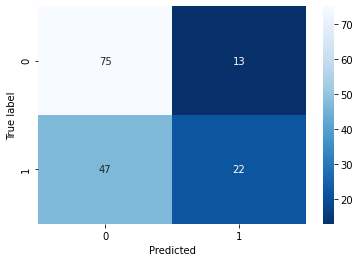

```python
print('Матрица ошибок модели'.center(50))
cm = confusion_matrix(y_test, y_pred)
sns.heatmap(cm, annot=True, fmt='d', cmap='Blues_r')
plt.ylabel('True label')
plt.xlabel('Predicted');
```

Ошибка первого рода, что модель присвоит признак "вкусно" невкусному молоку для фермера является критичнее при покупке коров, поэтому метрика recall в данном случае более важная. Поэтому сведем критичную ошибку к нулю: для этого изменим порог принадлежности к классам.

```python
y_proba = clf.predict_proba(X_test)[:,1]
data = pd.DataFrame(zip(y_test, y_proba),
             columns = ['y_valid', 'y_proba']).sort_values(by='y_proba',ascending=False)
data ['y_valid'] = data ['y_valid'].apply(lambda x: 1 if x == 'вкусно' else 0)
thresholds = [round(i,2) for i in np.linspace(0.6, 0.8, num = 6, endpoint=False)]
columns = []
# добавим столбцы с новыми предсказаниями в таблицу
for i in thresholds:
    columns.append('y_pred_'+str(i))
    data['y_pred_'+str(i)] = data['y_proba'].apply(lambda y_proba: 1 if y_proba <= i else 0)
# выведем 5 случайных строк
print(data.sample(5))
```

```
     y_valid   y_proba  y_pred_0.6  y_pred_0.63  y_pred_0.67  y_pred_0.7  \
145        1  0.213939           1            1            1           1
130        0  0.483503           1            1            1           1
36         1  0.391762           1            1            1           1
86         1  0.292195           1            1            1           1
94         0  0.416381           1            1            1           1

     y_pred_0.73  y_pred_0.77
145            1            1
130            1            1
36             1            1
86             1            1
94             1            1
```

```python
col = ['y_pred_0.6', 'y_pred_0.63', 'y_pred_0.67', 'y_pred_0.7', 'y_pred_0.73', 'y_pred_0.77']
for i in col:
    print (f'Точность, с которой модель присаивает признак "вкусно" (recall) при пороге {i} =', recall_score (data['y_valid'], data[i]))
```

```
Точность, с которой модель присаивает признак "вкусно" (recall) при пороге y_pred_0.6 = 0.9090909090909091
Точность, с которой модель присаивает признак "вкусно" (recall) при пороге y_pred_0.63 = 0.9318181818181818
Точность, с которой модель присаивает признак "вкусно" (recall) при пороге y_pred_0.67 = 0.9886363636363636
Точность, с которой модель присаивает признак "вкусно" (recall) при пороге y_pred_0.7 = 1.0
Точность, с которой модель присаивает признак "вкусно" (recall) при пороге y_pred_0.73 = 1.0
Точность, с которой модель присаивает признак "вкусно" (recall) при пороге y_pred_0.77 = 1.0
```

```python
precision_score (data['y_valid'], data['y_pred_0.7'])
```

```
0.5751633986928104
```

```python
X_test.sample()
```

|  | x0_свыше_0.9 | x1_РефлешнСоверинг | x2_Холмистое | x3_Соверин | x4_менее_2_лет | milk_yield_kg | EKE | row_protein_g | fat_% | protein_% |
| --- | --- | --- | --- | --- | --- | --- | --- | --- | --- | --- |
| 132 | 1.0 | 1.0 | 1.0 | 0.0 | 0.0 | 0.923568 | 0.431501 | 0.212196 | 0.562532 | -1.839317 |

Для прогноза вкуса молока у коров, предлагаемых к покупке, приведем датасет с информацией о них к виду, подходящему для прогноза:

```python
cow_buy_taste = cow_buy.drop(['dads_name'], axis =1)
cow_buy_taste ['EKE'] = (ferma['EKE'].mean() * 1.05)
cow_buy_taste ['row_protein_g'] = ferma['row_protein_g'].mean() * 1.05
cow_buy_taste ['SPO'] = 0.913116*1.05
cow_buy_taste ['SPO'] = cow_buy_taste ['SPO'].apply (lambda x: 'до_0.9' if x<=0.9 else 'свыше_0.9')
cow_buy_taste ['milk_yield_kg'] = cow_buy_yield ['milk_yield_kg']
cow_buy_taste = cow_buy_taste [['SPO', 'breed', 'pasture_type', 'dads_breed', 'age', 'milk_yield_kg', 'EKE', 'row_protein_g', 'current_fat_%', 'current_protein_%']]

cat_col_names = ['SPO', 'breed', 'pasture_type', 'dads_breed', 'age']
num_col_names = ['milk_yield_kg', 'EKE', 'row_protein_g', 'current_fat_%', 'current_protein_%']

cow_buy_taste_ohe = encoder.transform(cow_buy_taste[cat_col_names])
encoder_col_names = encoder.get_feature_names()
cow_buy_taste_scaled = scaler.transform(cow_buy_taste[num_col_names])

cow_buy_taste_ohe = pd.DataFrame(cow_buy_taste_ohe, columns=encoder_col_names)
cow_buy_taste_scaled = pd.DataFrame(cow_buy_taste_scaled, columns=num_col_names)
```

Применим обученную модель для прогноза вкуса молока с учетом порога классификации = 0.7:

```python
cow_buy_taste = pd.concat([cow_buy_taste_ohe, cow_buy_taste_scaled], axis=1)
cow_buy_taste ['y_proba'] = clf.predict_proba(cow_buy_taste)[:,1]
cow_buy_taste ['milk_taste'] = cow_buy_taste ['y_proba'].apply (lambda x: 'вкусно' if x>= 0.7 else 'не вкусно')
cow_buy_taste[cow_buy_taste ['milk_taste'] == 'вкусно']
```

|  | x0_свыше_0.9 | x1_РефлешнСоверинг | x2_Холмистое | x3_Соверин | x4_менее_2_лет | milk_yield_kg | EKE | row_protein_g | current_fat_% | current_protein_% | y_proba | milk_taste |
| --- | --- | --- | --- | --- | --- | --- | --- | --- | --- | --- | --- | --- |
| 5 | 1.0 | 1.0 | 0.0 | 1.0 | 1.0 | 0.630476 | 0.56625 | 0.517384 | 0.141686 | -8.800805 | 0.908365 | вкусно |
| 10 | 1.0 | 0.0 | 1.0 | 1.0 | 0.0 | 0.463519 | 0.56625 | 0.517384 | 0.742894 | -8.027306 | 0.792233 | вкусно |
| 12 | 1.0 | 0.0 | 1.0 | 0.0 | 0.0 | 1.012393 | 0.56625 | 0.517384 | 0.442290 | -11.508050 | 0.899320 | вкусно |
| 17 | 1.0 | 1.0 | 0.0 | 1.0 | 1.0 | 0.630476 | 0.56625 | 0.517384 | 0.983377 | -8.800805 | 0.909371 | вкусно |

С высокой долей вероятности вкусное молоко будут давать только 4 коровы из предлагаемых к покупке - коровы с id 5, 10, 12 и 17.

## 7. Итоговые выводы

**Исходные данные** о действующем стаде фермы, на которых была обучена модель, содержали информацию о 634 коровах, в том числе характеристики их корма и молока. В ходе предобработки данных приведены к удобному формату наименования столбцов для удобства их использования при написании кода, тип данных в столбце с информацией об уникальном номере коровы переведен в более подходящий текстовый формат, данные очищены от дубликатов, в том числе неявных (разное написание типов пастбищ и пород пап коров) и аномальных значений (коровы с характеристиками удоя молока свыше 10 000 кг в год). В результате предобработки данных количество коров, чьи характеристики использовались для обучения модели, сократилось до 628.

**Цель исследования** - спрогнозировать удой молока в кг в год и вкус молока у коров, предлагаемых к покупке, на основе данных коров в действующем стаде.

Исследовательский анализ выявил, что в действующем стаде:

- больше коров породы Вис Бик Айдиал (59%);
- больше коров (56%) пасутся на холмистых пастбищах;
- породы пап распределены примерно равномерно;
- 59 % коров имеют хорошие вкусовые качества молока;
- в стаде большинство коров (83%) старше 2 лет.

Анализ взамосвязей данных выявил, что на удой молока влияют:

- в большей степени питательность корма, отношение сахара к протеину в корме и возраст буренок;
- также прослеживаеется зависимость, но в меньшей степени, от содержание сырого протеина в корме и породы папы коровы.

При этом сильнее зависимость удоя молока от питательность корма прослеживается у коров, папы которых породы Айдиал, и коров старше 2 лет.

**Обучение модели** проведено по 2-м направлениям:

1. Для прогноза удоя молока использована модель линейной регрессии, для улучшения качества которой были разделены на 2 категории (до 0.9 и свыше 0.9) показатели отношения сахара к протеину в корме, возведены в квадрат показатели питальности корма для усиления линейности взаимосвязи признаков, а также добавлена информация о папах коров. Достигнута точность модели в 82,5 % случаев.
2. Для прогноза вкуса молока использована модель логистической регрессии с порогом классификации = 0.7 для повышения точности прогноза вкуса молока в целях исключения риска покупки коровы, дающей невкусное молоко.

Улучшить модель возможно в случае увеличения размера исходных данных, в том числе предоставления дополнительных характеристик о коровах, их корме или молоке.

В **результате** обученная на исходных данных модель спрогнозировала следующие характеристики удоя и вкуса молока у 20 предлагаемых к покупке коров при условии, что параметры корма ЭКЕ (энергетическая кормовая единица), сырой протеин и СПО (сахаро-протеиновое соотношение) для новых коров будет увеличена на 5%.

```python
cow_buy ['milk_yield_kg'] = cow_buy_yield ['milk_yield_kg']
cow_buy ['milk_taste'] = cow_buy_taste ['milk_taste']
cow_buy
```

|  | breed | pasture_type | dads_breed | dads_name | current_fat_% | current_protein_% | age | milk_yield_kg | milk_taste |
| --- | --- | --- | --- | --- | --- | --- | --- | --- | --- |
| 0 | Вис Бик Айдиал | Холмистое | Айдиал | Геркулес | 3.58 | 3.076 | более_2_лет | 6609.919297 | не вкусно |
| 1 | Вис Бик Айдиал | Равнинное | Соверин | Буйный | 3.54 | 3.081 | менее_2_лет | 6378.711028 | не вкусно |
| 2 | РефлешнСоверинг | Равнинное | Соверин | Барин | 3.59 | 3.074 | более_2_лет | 6283.999775 | не вкусно |
| 3 | РефлешнСоверинг | Холмистое | Айдиал | Буйный | 3.40 | 3.061 | более_2_лет | 6593.089377 | не вкусно |
| 4 | РефлешнСоверинг | Равнинное | Айдиал | Буйный | 3.64 | 3.074 | более_2_лет | 6542.146066 | не вкусно |
| 5 | РефлешнСоверинг | Равнинное | Соверин | Геркулес | 3.63 | 3.053 | менее_2_лет | 6425.380218 | вкусно |
| 6 | Вис Бик Айдиал | Холмистое | Айдиал | Геркулес | 3.58 | 3.076 | более_2_лет | 6609.919297 | не вкусно |
| 7 | Вис Бик Айдиал | Равнинное | Соверин | Буйный | 3.57 | 3.079 | более_2_лет | 6571.259737 | не вкусно |
| 8 | РефлешнСоверинг | Равнинное | Соверин | Барин | 3.59 | 3.074 | более_2_лет | 6283.999775 | не вкусно |
| 9 | РефлешнСоверинг | Холмистое | Айдиал | Буйный | 3.40 | 3.079 | менее_2_лет | 6400.540668 | не вкусно |
| 10 | Вис Бик Айдиал | Холмистое | Соверин | Соловчик | 3.73 | 3.055 | более_2_лет | 6344.707860 | вкусно |
| 11 | РефлешнСоверинг | Равнинное | Соверин | Геркулес | 3.73 | 3.073 | более_2_лет | 6617.928926 | не вкусно |
| 12 | Вис Бик Айдиал | Холмистое | Айдиал | Геркулес | 3.68 | 3.046 | более_2_лет | 6609.919297 | вкусно |
| 13 | Вис Бик Айдиал | Холмистое | Соверин | Барин | 3.42 | 3.075 | менее_2_лет | 6127.474742 | не вкусно |
| 14 | РефлешнСоверинг | Равнинное | Соверин | Барин | 3.59 | 3.074 | более_2_лет | 6283.999775 | не вкусно |
| 15 | РефлешнСоверинг | Холмистое | Айдиал | Буйный | 3.40 | 3.065 | более_2_лет | 6593.089377 | не вкусно |
| 16 | Вис Бик Айдиал | Холмистое | Соверин | Соловчик | 3.73 | 3.079 | более_2_лет | 6344.707860 | не вкусно |
| 17 | РефлешнСоверинг | Равнинное | Соверин | Геркулес | 3.77 | 3.053 | менее_2_лет | 6425.380218 | вкусно |
| 18 | Вис Бик Айдиал | Равнинное | Соверин | Буйный | 3.34 | 3.069 | более_2_лет | 6571.259737 | не вкусно |
| 19 | РефлешнСоверинг | Равнинное | Айдиал | Буйный | 3.64 | 3.074 | более_2_лет | 6542.146066 | не вкусно |

Таким образом, *для получения среднего удоя за год не менее 6 000 килограммов вкусного молока*, рекомендуются к покупке следующие коровы:

```python
cow_buy[(cow_buy['milk_yield_kg'] > 6000) & (cow_buy['milk_taste'] == 'вкусно')]
```

|  | breed | pasture_type | dads_breed | dads_name | current_fat_% | current_protein_% | age | milk_yield_kg | milk_taste |
| --- | --- | --- | --- | --- | --- | --- | --- | --- | --- |
| 5 | РефлешнСоверинг | Равнинное | Соверин | Геркулес | 3.63 | 3.053 | менее_2_лет | 6425.380218 | вкусно |
| 10 | Вис Бик Айдиал | Холмистое | Соверин | Соловчик | 3.73 | 3.055 | более_2_лет | 6344.707860 | вкусно |
| 12 | Вис Бик Айдиал | Холмистое | Айдиал | Геркулес | 3.68 | 3.046 | более_2_лет | 6609.919297 | вкусно |
| 17 | РефлешнСоверинг | Равнинное | Соверин | Геркулес | 3.77 | 3.053 | менее_2_лет | 6425.380218 | вкусно |

*Рекомендации:*

1. Покупка 4 коров из предлагаемых 20, у которых минимальные риски неполучения требуемых характеристик удоя и вкуса молока.
2. Рассмотреть иных коров к покупке, используя разработанную модель прогноза удоя и вкуса молока.
3. Повысить питательность корма для повышения удоя для коров старше 2-лет, папы которых породы Айдиал.
4. Улучшить модель, добавив в нее дополнительные характеристики коров, корма и/или молока.
5. Усилить контроль за наполнением исходных данных в целях устранения аномальных значений и повторяющихся строк.